# permutation testing in the tidyverse

## unequal variance

Resampling methods for t-tests and ANOVA randomize the labels associated with the observations, so that actually assume equal variance among the groups.

**The following is not true, but I’m including it because it took a lot of work!:**

(That said, I think this is a fine way to bootstrap a confidence interval of differences in means between groups.)

According to Good (*Resampling Methods: A practical guide to data analysis*), one way around this assumption of equal variance is to bootstrap the differences in means between the groups, bootstrapping *within* each group then taking the difference of the means. If the observed differences are not just due to chance, we’d expect the 95% CI of the bootstrapped means to exclude the observed difference.

Importantly, you must sample based on the null hypothesis that there is no average difference in the means between the groups.

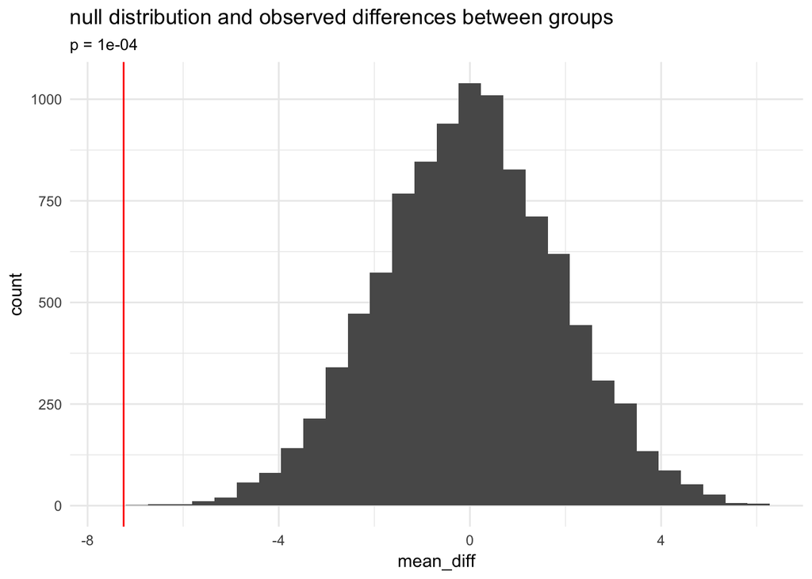

```r
bootstrap_within_groups <- function(df, group, variable, replicates = 999, seed = NULL) {
  group_enquo <- enquo(group)
  variable_enquo <- enquo(variable)

  group_vector <- pull(df, !!group_enquo)
  variable_vector <- pull(df, !!variable_enquo)

  # subtract the mean of mpg from each group to simulate under H0 that there's no difference between the groups
  variable_vector <- variable_vector - ave(variable_vector, group_vector)


  # make sure there are only two groups
  stopifnot(length(levels(factor(group_vector))) == 2)

  get_diff <- function(var, grp) {
    split(var, grp) %>%
      map(sample, replace = T) %>%
      map(mean) %>%
      unlist %>%
      Reduce(`-`, .)
  }

  if(!is.null(seed)) set.seed(seed)
  out <- replicate(replicates, get_diff(variable_vector, group_vector))

  data.frame(replicate = 1:replicates, mean_diff = out)

}

# define number of samples to draw
n <- 9999

# get the observed difference
observed <- mtcars %>% split(.$am) %>% map(~ mean(.$mpg)) %>% unlist %>% Reduce(`-`, .)

booted <- mtcars %>%
  nest %>%
  mutate(rep = map(data,
                         bootstrap_within_groups,
                         group = am,
                         variable = mpg,
                         replicates = n,
                         seed = 10)) %>%
  unnest(rep)

p <- (sum(abs(booted$mean_diff) > ifelse(observed > 0, observed, -observed)) + 1) / (n+1)

booted %>%
  ggplot(aes(x= mean_diff)) +
  geom_histogram() +
  geom_vline(xintercept = observed, color = "red") +
  theme_minimal() +
  ggtitle("null distribution and observed differences between groups",
          subtitle = paste0("p = ", p))
```

We can compare that to a t-test:

```r
t.test(mpg ~ am, data = mtcars)
```

```
##
##  Welch Two Sample t-test
##
## data:  mpg by am
## t = -3.7671, df = 18.332, p-value = 0.001374
## alternative hypothesis: true difference in means is not equal to 0
## 95 percent confidence interval:
##  -11.280194  -3.209684
## sample estimates:
## mean in group 0 mean in group 1
##        17.14737        24.39231
```